# ggplot Demo

KJF

March 27, 2018

## Script to demo ggplot use of factors

Load packages and demo Sunapee data

```r
library(tidyverse)
library(lubridate)

raw <- read_csv("LMP_L1daily_temp_merge.csv")

names(raw)
```

```
##  [1] "date"            "loc"             "Temp_0m_degC"
##  [4] "Temp_0p1m_degC"  "Temp_0p5m_degC"  "Temp_1m_degC"
##  [7] "Temp_1p5m_degC"  "Temp_1p9m_degC"  "Temp_2m_degC"
## [10] "Temp_2p5m_degC"  "Temp_3m_degC"    "Temp_3p5m_degC"
## [13] "Temp_4m_degC"    "Temp_4p5m_degC"  "Temp_5m_degC"
## [16] "Temp_5p5m_degC"  "Temp_6m_degC"    "Temp_6p5m_degC"
## [19] "Temp_7m_degC"    "Temp_7p5m_degC"  "Temp_8m_degC"
## [22] "Temp_8p3m_degC"  "Temp_8p5m_degC"  "Temp_8p7m_degC"
## [25] "Temp_9m_degC"    "Temp_9p17m_degC" "Temp_9p5m_degC"
## [28] "Temp_10m_degC"   "Temp_10p5m_degC" "Temp_11m_degC"
## [31] "Temp_11p5m_degC" "Temp_12m_degC"   "Temp_12p5m_degC"
## [34] "Temp_13m_degC"   "Temp_13p5m_degC" "Temp_14m_degC"
## [37] "Temp_14p5m_degC" "Temp_15m_degC"   "Temp_15p5m_degC"
## [40] "Temp_16m_degC"   "Temp_16p5m_degC" "Temp_17m_degC"
## [43] "Temp_17p5m_degC" "Temp_18m_degC"   "Temp_18p5m_degC"
## [46] "Temp_19m_degC"   "Temp_19p2m_degC" "Temp_19p5m_degC"
## [49] "Temp_20m_degC"   "Temp_20p5m_degC" "Temp_21m_degC"
## [52] "Temp_21p5m_degC" "Temp_21p9m_degC" "Temp_22m_degC"
## [55] "Temp_22p5m_degC" "Temp_23m_degC"   "Temp_23p5m_degC"
## [58] "Temp_24m_degC"   "Temp_24p5m_degC" "Temp_25m_degC"
## [61] "Temp_25p5m_degC" "Temp_26m_degC"   "Temp_26p5m_degC"
## [64] "Temp_27m_degC"   "Temp_27p5m_degC" "Temp_28m_degC"
## [67] "Temp_28p5m_degC" "Temp_29m_degC"   "Temp_29p5m_degC"
## [70] "Temp_30m_degC"   "Temp_31m_degC"   "Temp_32m_degC"
## [73] "Temp_33m_degC"   "datasource"
```

Whoa, those column names are out of control!  
We’ll have to massage the data into a more user-friendly format:

```r
startDate = ymd('2005-01-01')

manualTemp <- raw %>%
  filter(date >= startDate) %>% # Retain dates on or after start date
  select(-datasource) %>% # Drop datasource column
  rename_at(vars(starts_with("Temp_")), funs(sub("Temp_", "", .))) %>% # 3 steps
  rename_at(vars(ends_with("_degC")), funs(sub("m_degC","",.))) %>% # to streamline
  rename_at(vars(contains("p")), funs(sub("p", ".",.))) %>% # column names
  gather(Depth, Temp, "0":"33") %>% # Reshape wide to long
  mutate(Depth = as.double(Depth), Temp = round(as.double(Temp), 2)) %>% # Parse Depth and Temp
  na.omit() # Remove rows with NA values

head(manualTemp)
```

```
## # A tibble: 6 x 4
##   date       loc   Depth  Temp
##   <date>     <chr> <dbl> <dbl>
## 1 2007-08-28 buoy     0.  23.0
## 2 2007-08-29 buoy     0.  23.2
## 3 2007-08-30 buoy     0.  23.5
## 4 2007-08-31 buoy     0.  23.2
## 5 2007-09-01 buoy     0.  22.1
## 6 2007-09-02 buoy     0.  21.6
```

Much better!  
Note that while we specificed Depth and temp as being double, loc is currently parsed as a character.

If you make a plot of temperature over time with depths as different colors, the depths default to a color gradient, since their structure is “double”:

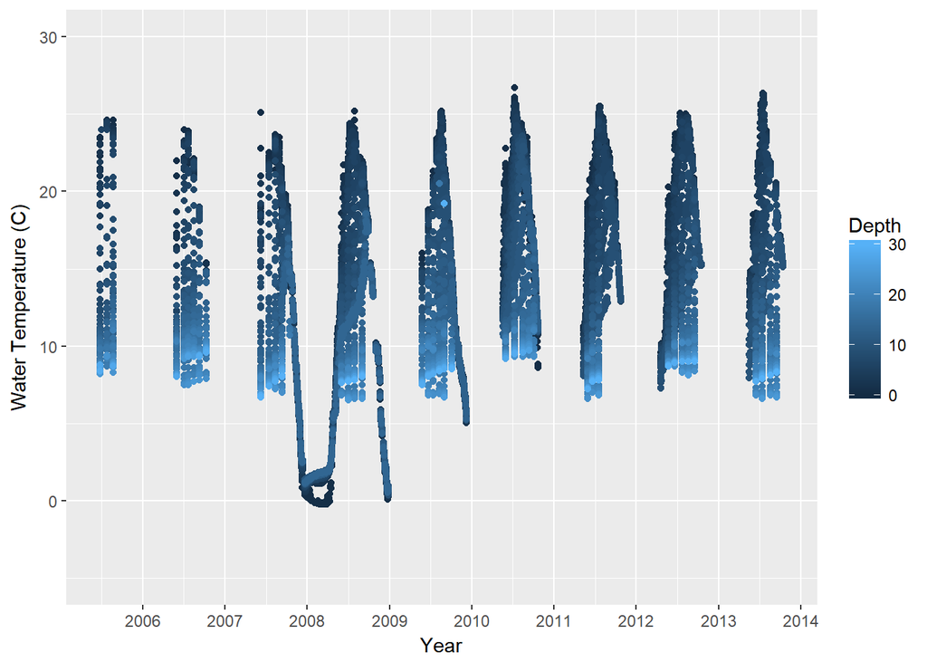

```r
ggplot(manualTemp, aes(x = date, y = Temp, col = Depth)) +
  geom_point() +
  scale_y_continuous("Water Temperature (C)", limits= c(-5,30)) +
  scale_x_date("Year", date_breaks= "1 year", date_labels= "%Y")
```

If, instead, you want discrete colors, you would set Depth as a factor. You can do this in the ggplot command directly.

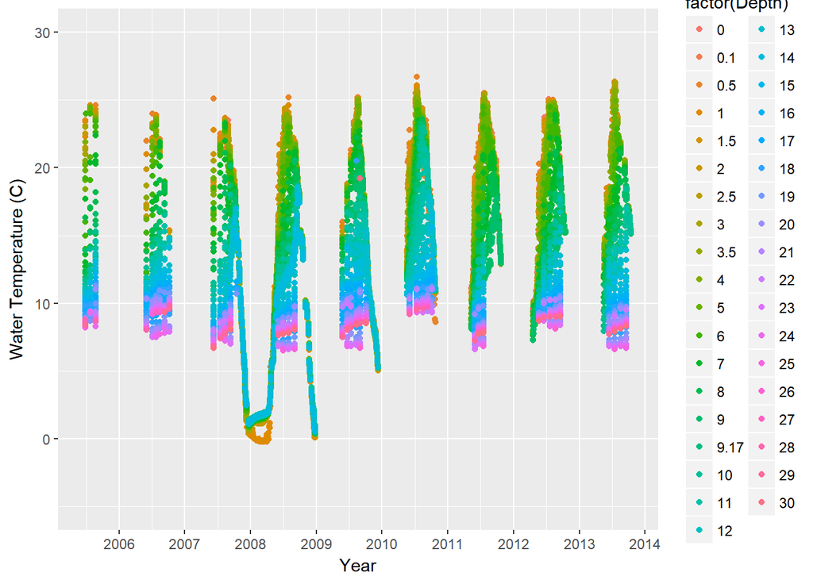

```r
ggplot(manualTemp, aes(x = date, y = Temp, col = factor(Depth))) +
  geom_point() +
  scale_y_continuous("Water Temperature (C)", limits= c(-5,30)) +
  scale_x_date("Year", date_breaks= "1 year", date_labels= "%Y")
```

Note that for these plots, you’re lumping all the locations together. Maybe you just want to look at 210 and the buoy at 1, 10, and 20 meters.

```r
manTemp <- manualTemp %>%
  filter((loc == '210' | loc=='buoy') & (Depth %in% c(1, 10, 20)))
```

Now we’ll plot with each location as a shape and each depth as a color:

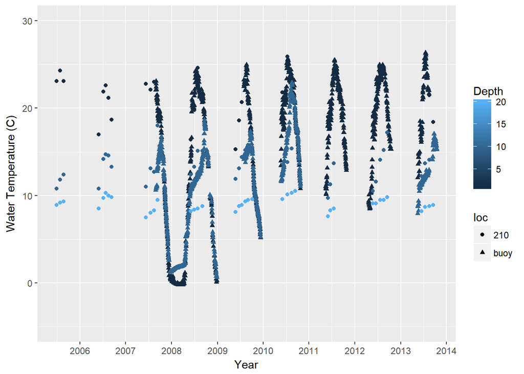

```r
ggplot(manTemp, aes(x = date, y = Temp, pch = loc, col = Depth)) +
  geom_point() +
  scale_y_continuous("Water Temperature (C)", limits= c(-5,30)) +
  scale_x_date("Year", date_breaks= "1 year", date_labels= "%Y")
```

Here, it’s disingenuous to have Depth as a color gradient, because we’re only looking at 3 discrete depths. Thus we need to have it as a factor!  
We could add factor() to the aes in the plotting command, as we did above, or recode Depth as a factor in the tibble itself:

```r
manTemp <- manTemp %>%
  mutate(Depth = factor(Depth))

head(manTemp)
```

```
## # A tibble: 6 x 4
##   date       loc   Depth  Temp
##   <date>     <chr> <fct> <dbl>
## 1 2005-06-27 210   1      23.1
## 2 2005-07-25 210   1      24.3
## 3 2005-08-22 210   1      23.1
## 4 2006-05-31 210   1      17.0
## 5 2006-07-05 210   1      21.9
## 6 2006-07-24 210   1      22.6
```

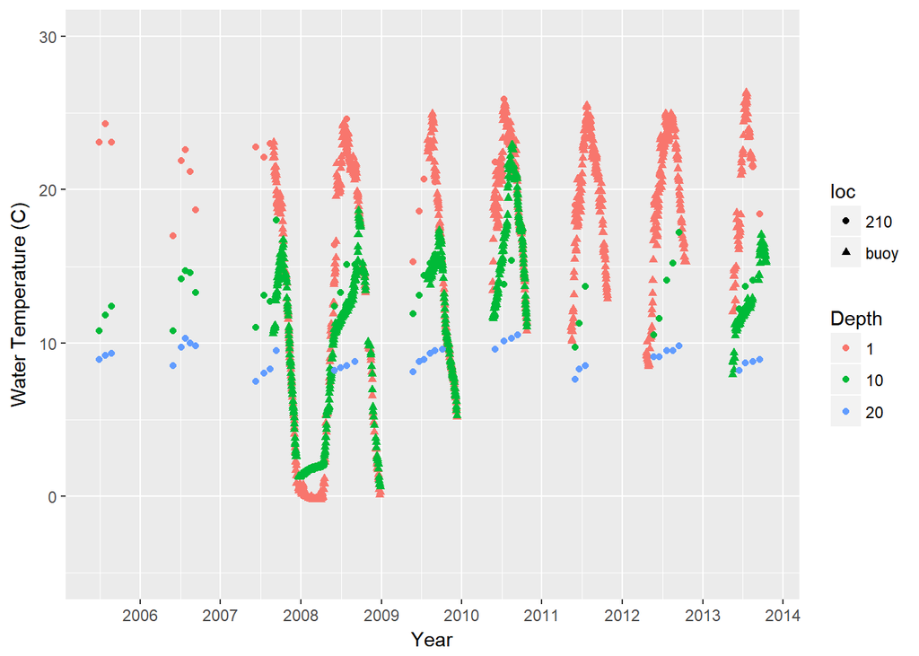

```r
ggplot(manTemp, aes(x = date, y = Temp, pch = loc, col = Depth)) +
  geom_point() +
  scale_y_continuous("Water Temperature (C)", limits= c(-5, 30)) +
  scale_x_date("Year", date_breaks= "1 year", date_labels= "%Y")
```

Notice how instead of using subset commands to select each location or depth, you add them in to the aes command, and they’re automatically added to the legend. Whoo!